# Basic Tutorial

Dana Gibbon

2019-12-13

# Quick start

- Install `PressPurt`

```r
# Specify branch and build vignettes
devtools::install_github("dkoslicki/PressPurt",
                         subdir = "R_version",
                         build_vignettes = FALSE)
```

- Load the library
- Check available python versions
- Set python with previously made conda environment
- Install python dependencies
- Run PreprocessMatrix
- Run ComputeEntryWisePerturbationExpectation
- Plot
  - specific figures
  - all figures

```r
library(PressPurt)
find_python()
```

```
#> Default Python:
#>  /home/gibbond/anaconda3/envs/r-reticulate/bin/python
#>
#>  Python versions found:
#>  /home/gibbond/anaconda3/envs/r-reticulate/bin/python /usr/bin/python /usr/bin/python3 /home/gibbond/anaconda3/bin/python /home/gibbond/.virtualenvs/bleh/bin/python /home/gibbond/.virtualenvs/PressPurt/bin/python /home/gibbond/.virtualenvs/Test/bin/python /home/gibbond/anaconda3/envs/bleh/bin/pyt…
#>
#>  List of condaenvironments:
#>  : ,
#>
#>  List of virtualenvs:
#>  bleh PressPurt Test
```

```r
set_python_virtual("PressPurt", verbose = TRUE)
```

```
#>
#>  Setting virtual environment
#>
#>  Python/virtual environment in use:
#> python:         /home/gibbond/.virtualenvs/PressPurt/bin/python
#> libpython:      /home/gibbond/anaconda3/envs/r-reticulate/lib/libpython3.6m.so
#> pythonhome:     /home/gibbond/anaconda3/envs/r-reticulate:/home/gibbond/anaconda3/envs/r-reticulate
#> version:        3.6.7 |Anaconda, Inc.| (default, Oct 23 2018, 19:16:44)  [GCC 7.3.0]
#> numpy:          /home/gibbond/.virtualenvs/PressPurt/lib/python3.6/site-packages/numpy
#> numpy_version:  1.16.3
#>
#> NOTE: Python version was forced by use_python function
```

```r
py_depend(virtualenv = "PressPurt")
```

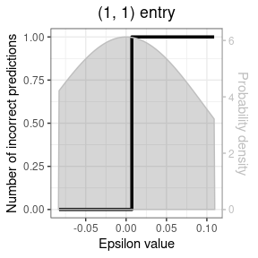

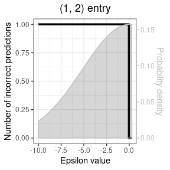

```r
# Path to your matrix - in this case a test dataset that comes with the package
infile <- system.file("extdata", "Modules", "IGP.csv", package = "PressPurt")
MultiPert <- ComputeMultiEntryPerturbationExpectation(input_file = infile)
PreProsMatrix <- PreprocessMatrix(input_file = infile,
                                  output_folder = NULL,
                                  max_bound = 10,
                                  threads = 2)
Entrywise <- ComputeEntryWisePerturbationExpectation(PreProsMatrix = PreProsMatrix,
                                        distribution_type="truncnorm",
                                        input_a=0, input_b=-2, threads=1)
list_of_numswitch_to_plot <- list(c(1, 1), c(1, 2))
GenerateEntryWiseFigures(EntryWise=Entrywise,
                         all_numswitch_plots = FALSE,
                         list_of_numswitch_to_plot=list_of_numswitch_to_plot)
```

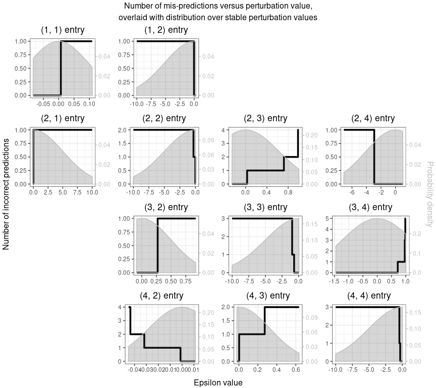

```r
GenerateEntryWiseFigures(EntryWise=Entrywise,
                         all_numswitch_plots = TRUE)
```

# Load Python

This package uses python through the R package `reticulate`. You’ll need to install the needed python libraries into a conda env or a virtualenv. The “dependencies_tutorial” walks you through how to do this. Once this is done, you’ll need to load your conda env or virtualenv.

Note: If you want to change conda envs or virtual envs, you’ll need to restart R because of how `reticulate` works.

```r
# set the conda env
set_python_virtual("PressPurtEnv", verbose = TRUE)
```

# Example: IGP.csv

When running this workflow, one may keep everything in R memory or save the output and intermediate files to a specified folder. However, many of these output files are python objects. Let’s start by looking at the R-based version:

## R-object based

### Compute Multi Entry Perturbation Expectation

This function takes a jacobian matrix and computes the multi-entry perturbation expectation.

In this example we take the `IGP.csv` matrix and use the default `num_iterates` and `interval_length` values.

The `IGP.csv` file is an example dataset that is included in the `PressPurt` package.

```r
infile <- system.file("extdata", "Modules", "IGP.csv", package = "PressPurt")
MultiPert <- ComputeMultiEntryPerturbationExpectation(input_file = infile)
MultiPert
```

```
#> [1] 0.266
```

### PreprocessMatrix

This function pre-processes a matrix by figuring out what the intervals of asymptotic stability are, as well as finding which perturbation values lead to a sign switch.

In this example we use a `max_bound` of 10, don’t perturb zero entries and use 2 threads.

```r
PreProsMatrix <- PreprocessMatrix(input_file = infile,
                                  max_bound = 10,
                                  zero_perturb = FALSE,
                                  threads = 2)
```

#### Output

The output is a list of 9 objects which includes: original_matrix, matrix_size, column_names, row_names, non_zero, num_switch_functions_py, asymptotic_stability_start, asymptotic_stability_end, num_switch_funcs_r

##### Matrix

This includes the original matrix and information about that matrix:

```r
# Original Matrix
PreProsMatrix$original_matrix
```

```
#>        [,1]   [,2]   [,3]   [,4]
#> [1,] -0.237 -1.000  0.000  0.000
#> [2,]  0.100 -0.015 -1.000 -1.000
#> [3,]  0.000  0.100 -0.015 -1.000
#> [4,]  0.000  0.045  0.100 -0.015
```

```r
# Matrix size
PreProsMatrix$matrix_size
```

```
#> [1] 4
```

```r
# row names
PreProsMatrix$row_names
```

```
#> [1] "0" "1" "2" "3"
```

```r
# column names
PreProsMatrix$column_names
```

```
#> [1] "0" "1" "2" "3"
```

```r
# number of entries that aren't zero
PreProsMatrix$non_zero
```

```
#> [1] 12
```

##### Asymptotic of Stability intervals

The asymptotic of stability intervals are divided up into two matrices: start and stop.

```r
# Start
PreProsMatrix$asymptotic_stability_start
```

```
#>             [,1]         [,2]         [,3]       [,4]
#> [1,] -0.08298658  -9.99999999   0.00000000   0.000000
#> [2,] -0.02593439  -9.99999999  -0.25212423  -7.117953
#> [3,]  0.00000000  -0.08404049  -9.99999999  -1.448616
#> [4,]  0.00000000  -0.04499999  -0.02042571 -10.000000
```

```r
# End
PreProsMatrix$asymptotic_stability_end
```

```
#>            [,1]       [,2]       [,3]       [,4]
#> [1,]  0.1090182 0.25934395 0.00000000 0.00000000
#> [2,] 10.0000000 0.01499999 0.99999999 0.99999999
#> [3,]  0.0000000 0.91947448 0.01499999 0.99999999
#> [4,]  0.0000000 0.01113441 0.63448010 0.01499999
```

```r
# To access entry 1,1:
PreProsMatrix$asymptotic_stability_start[1,1]
```

```
#> [1] -0.08298658
```

```r
PreProsMatrix$asymptotic_stability_end[1,1]
```

```
#> [1] 0.1090182
```

##### Num Switch

The `num_switch_funcs` object is a list of each non-zero entry in the matrix and the corresponding perturbation values that leads to a sign switch.

For example, entry 1,1 has 1 sign switch and 2,2 has 2.

```r
# get the length of the list, see it's
# the same as the non-zero entries
length(PreProsMatrix$num_switch_funcs_r)
```

```
#> [1] 12
```

```r
# see the names of the entries
names(PreProsMatrix$num_switch_funcs_r)
```

```
#>  [1] "(1, 1)" "(1, 2)" "(2, 1)" "(2, 2)" "(2, 3)" "(2, 4)" "(3, 2)" "(3, 3)"
#>  [9] "(3, 4)" "(4, 2)" "(4, 3)" "(4, 4)"
```

```r
# num switch function for 1,1
PreProsMatrix$num_switch_funcs_r$`(1, 1)`
```

```
#>   num_switch_val       start       end
#> 1              1 0.007114943 0.1090182
```

```r
# num switch function for 2,2
PreProsMatrix$num_switch_funcs_r$`(2, 2)`
```

```
#>   num_switch_val       start         end
#> 1              1  -0.3125131 -0.01305907
#> 2              2 -10.0000000 -0.31251310
```

You can ignore the `num_switch_functions_py` object as it is a python dictionary that is passed to the next step.

### Compute Entry Wise Perturbation Expectation

This function computes the expected number of sign switches from perturbing each entry individually.

In this example, the `PreProsMatrix` object is passed, “truncnorm” distribution is used, `input_a` is 0 and `input_b` is -2.

```r
Entrywise <- ComputeEntryWisePerturbationExpectation(PreProsMatrix = PreProsMatrix,
                                        distribution_type="truncnorm",
                                        input_a=0, input_b=-2, threads=1)
```

#### Output

The output includes the same object that were found in `PreProsMatrix` with 3 additions: original_matrix, matrix_size, column_names, row_names, non_zero, num_switch_functions_py, asymptotic_stability_start, asymptotic_stability_end, num_switch_funcs_r, expected_num_switch, distributions_object, ns_object_plot

##### Expected num switch

This is a data frame of expected sign switches.

```r
Entrywise$expected_num_switch
```

```
#>            0          1          2           3
#> 0 0.03155098 0.05964785 0.00000000 0.000000000
#> 1 0.06219858 0.12130032 0.05215649 0.021873797
#> 2 0.00000000 0.03050608 0.15946639 0.008706269
#> 3 0.00000000 0.05350997 0.08104533 0.174734087
```

##### Distributions Object

This object gets the probability density distribution into a plot ready format for each non-zero interval in the matrix. By default there are 250 points in the distribution.

```r
# distributions object of each non-zero entry in the matrix
names(Entrywise$distributions_object)
```

```
#>  [1] "(1, 1)" "(1, 2)" "(2, 1)" "(2, 2)" "(2, 3)" "(2, 4)" "(3, 2)" "(3, 3)"
#>  [9] "(3, 4)" "(4, 2)" "(4, 3)" "(4, 4)"
```

```r
# position in the matrix
Entrywise$distributions_object$`(1, 1)`[1]
```

```
#> $position
#> [1] 1 1
```

```r
# Interval of asymptotic of stability
Entrywise$distributions_object$`(1, 1)`[2]
```

```
#> $interval
#> [1] -0.08298658  0.10901820
```

```r
# ready to plot probability density distribution dataframe
head(Entrywise$distributions_object$`(1, 1)`[[3]], n = 10)
```

```
#>        x_range dist_vals
#> 1  -0.08375460  0.000000
#> 2  -0.08297733  4.217092
#> 3  -0.08220006  4.246567
#> 4  -0.08142278  4.275968
#> 5  -0.08064551  4.305290
#> 6  -0.07986824  4.334529
#> 7  -0.07909097  4.363681
#> 8  -0.07831369  4.392740
#> 9  -0.07753642  4.421704
#> 10 -0.07675915  4.450566
```

##### Num Switch Object

The `ns_object_plot` is the Num Switch functions that have been converted into step functions and are ready to plot!

```r
# Step function for each non-zero entry in the matrix
names(Entrywise$ns_object_plot)
```

```
#>  [1] "(1, 1)" "(1, 2)" "(2, 1)" "(2, 2)" "(2, 3)" "(2, 4)" "(3, 2)" "(3, 3)"
#>  [9] "(3, 4)" "(4, 2)" "(4, 3)" "(4, 4)"
```

```r
# entry 1,1
Entrywise$ns_object_plot$`(1, 1)`
```

```
#>            nsx nsy
#> 1 -0.082986581   0
#> 2  0.007114943   0
#> 3  0.109018199   1
```

```r
# entry 4,2
Entrywise$ns_object_plot$`(4, 2)`
```

```
#>            nsx nsy
#> 6 -0.044999990   4
#> 5 -0.043500000   4
#> 4 -0.043500000   3
#> 3 -0.031798604   2
#> 2 -0.001305907   1
#> 1  0.011134411   0
```

The y-0 position has been added to the step function:

```r
# Before
Entrywise$num_switch_funcs_r$`(1, 1)`
```

```
#>   num_switch_val       start       end
#> 1              1 0.007114943 0.1090182
```

```r
# After - step function
Entrywise$ns_object_plot$`(1, 1)`
```

```
#>            nsx nsy
#> 1 -0.082986581   0
#> 2  0.007114943   0
#> 3  0.109018199   1
```

### Generate Entry Wise Figures

The `GenerateEntryWiseFigures` function plots the Num Switch step function on the Y-axis in black and the probability density on the Y-axis in grey.

One may plot individual entries or a list of entries with the `list_of_numswitch_to_plot` option:

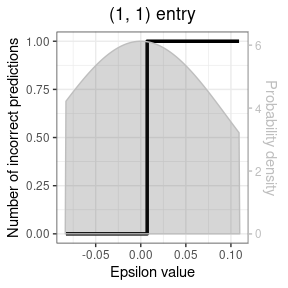

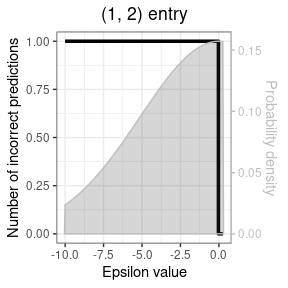

```r
list_of_numswitch_to_plot <- list(c(1, 1), c(1, 2))
GenerateEntryWiseFigures(EntryWise=Entrywise,
                         all_numswitch_plots = FALSE,
                         list_of_numswitch_to_plot=list_of_numswitch_to_plot)
```

Or plot all figures with `all_numswitch_plots`.

For large matrices it is not recommended that you plot them all in one plot.

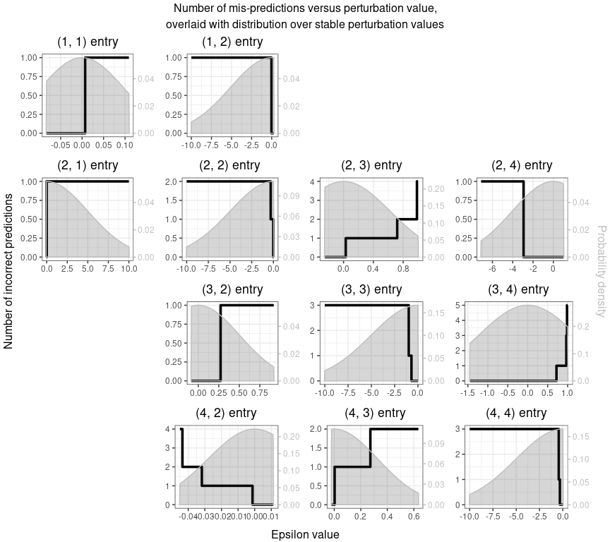

```r
GenerateEntryWiseFigures(EntryWise=Entrywise,
                         all_numswitch_plots = TRUE)
```

## Save to disk

### Basic pipeline

One may instead save objects to disk if one sets an `output_folder`. The following files will be created in the specified folder:

- asymptotic_stability.npy
- distributions.pkl
- num_non_zero.npy
- row_names.txt
- column_names.txt
- expected_num_switch.csv
- num_switch_funcs.pkl
- size.npy

If you are going to be doing multiple runs in the same folder it is recommended that you specify a file prefix - this will add _ to the beginning of every file.

```r
# Not run in vignette creation
PreProsMatrix <- PreprocessMatrix(input_file = infile,
                                  output_folder = "test_r/test4",
                                  prefix = "IGP", max_bound = 10, threads = 2)
Entrywise <- ComputeEntryWisePerturbationExpectation(input_folder = "test_r/test4",
                                                     prefix = "IGP",
                                                     distribution_type="truncnorm",
                                                     input_a=0, input_b=-2, threads=1)

list_of_numswitch_to_plot <- list(c(1, 1), c(1, 2))
GenerateEntryWiseFigures(input_folder = "test_r/test4",
                         prefix = "IGP",
                         all_numswitch_plots = FALSE,
                         list_of_numswitch_to_plot=list_of_numswitch_to_plot)
```

Many of them are numpy or pickle python objects. But the `GenerateEntryWiseFigures` can handle them!

### Process Data

One may also turn the data saved to a folder into an R friendly format with `process_data`. This function will put the data in the same format as the output as `ComputeEntryWisePerturbationExpectation`.

```r
Entrywise_from_disk <- process_data(matrix = infile,
                                    type = "csv",
                                    folder = "test_r/test4",
                                    prefix = "IGP")
```

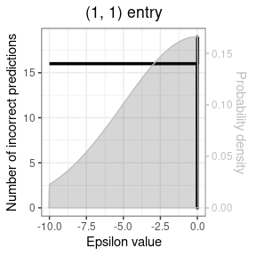

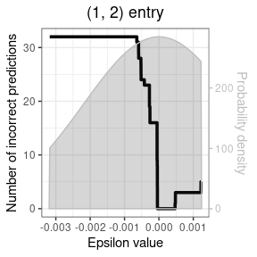

```r
# Path to the E.coli matrix
infile <- system.file("extdata", "Real", "Ecoli.csv", package = "PressPurt")
PreProsMatrix <- PreprocessMatrix(input_file = infile,
                                  output_folder = NULL,
                                  max_bound = 10,
                                  threads = 2)
Entrywise <- ComputeEntryWisePerturbationExpectation(PreProsMatrix = PreProsMatrix,
                                        distribution_type="truncnorm",
                                        input_a=0, input_b=-2, threads=1)
list_of_numswitch_to_plot <- list(c(1, 1), c(1, 2))
GenerateEntryWiseFigures(EntryWise=Entrywise,
                         all_numswitch_plots = FALSE,
                         list_of_numswitch_to_plot=list_of_numswitch_to_plot)
```